# Project Milestone #4 - Visualizations

Group 10: Ruby Yun, Jackie Zintel

2026-11-21

**1. Introduction**

This project investigates the geographic and demographic distribution of a simulated infectious disease outbreak across California, utilizing data from Scenario 1: Infectious disease outbreak in California in the PHW251 Project Data repository. Specifically, our primary research question is: **How did infection rates during the outbreak vary by county, age, sex, and race/ethnicity across California?**

To answer this question, we use simulated morbidity datasets for California and Los Angeles County, which include case counts along with individual demographic and geographic details. We also incorporate 2023 population estimates from the California Department of Finance. These population estimates provide the denominators needed to calculate infection rates per 100,000 population, allowing us to make meaningful comparisons across groups of different sizes. By combining morbidity and population data, this project aims to identify key demographic and geographic differences in infection rates during the outbreak.

**2. Import dataset**

**3. Data types and variables**

1. We chose the following variables: county, age_cat, sex, race_ethnicity, new_infections, population, dt_diagnosis
2. Desired data types for analysis:
- county, age category, sex, race/ethnicity, dt_diagnosis: character/categorical
- population and new infections: integer/numeric

**4. Data Cleaning**

1. Convert variables
- Rename columns
- Race/ethnicity
- County names
2. Recategorize age groups
3. Standardize dates

**5. Merge the datasets**

1. Combine sim_ca and sim_la in one dataset

```r
sim_combined <- bind_rows(sim_ca, sim_la)
```

2. Join population dataset

```r
# summarize ca_pop dataset before merging
ca_pop_clean <- ca_pop %>%
  group_by(county, age_cat, sex, race_ethnicity) %>%
  summarise(population = sum(pop, na.rm = TRUE), .groups = "drop")

# combine all datasets into one dataset
combined_df <- sim_combined %>%
  left_join(ca_pop_clean, by = c("county", "age_cat", "sex", "race_ethnicity"),
    relationship = "many-to-one")

str(combined_df)
```

**6. Data analysis**

There are extra variables that we don’t need in order to answer our research question. We simplified it to only include relevant information:

1. Select relevant information

```r
selected_df <- combined_df %>%
  select(county, age_cat, sex, race_ethnicity,
    dt_diagnosis, new_infections, population)

str(selected_df)
```

2. Check missing values

```r
# check missing values
colSums(is.na(selected_df))

# check invalid values
sum(selected_df$new_infections < 0, na.rm = TRUE)
sum(selected_df$population <= 0, na.rm = TRUE)

# count unique strata with invalid population values (<= 0)
selected_df %>%
  filter(population <= 0) %>%
  distinct(county, age_cat, sex, race_ethnicity, population) %>%
  nrow()
```

3. Create new variables
- Create a month variable to examine monthly infection trends

```r
selected_df <- selected_df %>%
  mutate(diagnosis_month = month(dt_diagnosis, label = TRUE, abbr = TRUE)) %>%
  select(-dt_diagnosis)

head(selected_df)
```

- Calculate infection rates

```r
aggregated_df <- selected_df %>%
  group_by(county, age_cat, sex, race_ethnicity) %>%
  summarize(
    total_infections = sum(new_infections, na.rm = TRUE),
    population = first(population),
    .groups = "drop") %>%
  mutate(
    infection_rate = if_else(
      population > 0,
      round(total_infections / population * 100000, 1),
      NA_real_))

head(aggregated_df)
```

**7. Data visualization**

Some observations had a population value of zero across multiple counties. Since population is used as the denominator when calculating infection rates, these observations cannot produce a valid rate. Therefore, observations with a population value of zero were excluded from the graphs and rate calculations only. The original dataset was retained without deleting these observations.

1. Monthly infection trend in California

```r
df_monthly <- selected_df %>%
  filter(population > 0) %>%
  group_by(diagnosis_month) %>%
  summarize(total_infections = sum(new_infections, na.rm = TRUE),
            .groups = "drop")

df_monthly %>% kable(
  col.names = c("Diagnosis Month", "Total Infections")) %>%
  kable_styling(bootstrap_options = "striped",
                full_width = FALSE,
                position = "center")
```

| Diagnosis Month | Total Infections |
| --- | --- |
| May | 13875 |
| Jun | 119964 |
| Jul | 440528 |
| Aug | 936490 |
| Sep | 1445805 |
| Oct | 1403725 |
| Nov | 181326 |
| Dec | 7863 |

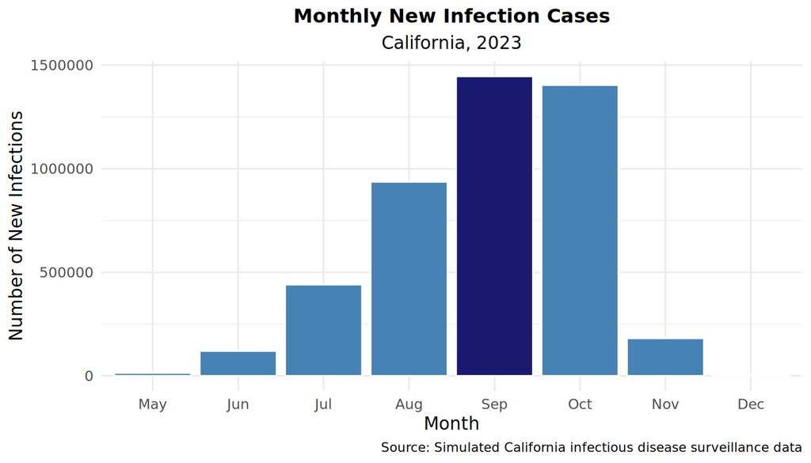

```r
peak_month <- max(df_monthly$total_infections)

ggplot(df_monthly,
       aes(x = diagnosis_month, y = total_infections)) +
  geom_col(
    aes(fill = ifelse(total_infections == peak_month, "peak", "other")),
           color = "white") +
  scale_fill_manual(values = c("peak" = "midnightblue", "other" = "steelblue"),
                    guide = "none") +
  labs(title = "Monthly New Infection Cases",
       subtitle = "California, 2023",
       x = "Month",
       y = "Number of New Infections",
       caption =
      "Source: Simulated California infectious disease surveillance data") +
  theme_minimal() +
  theme(plot.title = element_text(hjust = 0.5, size = 12, face = "bold"),
        plot.subtitle = element_text(hjust = 0.5, size = 11),
        plot.caption = element_text(size = 8, hjust = 1))
```

**Interpretation:** The bar graph shows that monthly new infections increased steadily from May through September, reaching their peak in September before declining in October and November. This pattern suggests that the outbreak intensified throughout the summer months and began to subside in the fall.

2. Infection rate by county

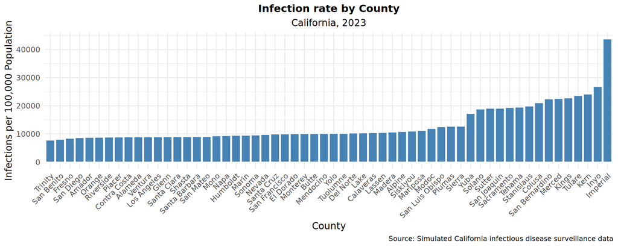

```r
df_county <- aggregated_df %>%
  filter(population > 0) %>%
  group_by(county) %>%
  summarize(total_infections = sum(total_infections),
            population = sum(population),
            .groups = "drop") %>%
  mutate(
    infection_rate = round
    (total_infections/population * 100000, 1)
         )

ggplot(df_county,
       aes(x = reorder(county, infection_rate), y = infection_rate)) +
  geom_col(fill = "steelblue", color = "white") +
  labs(title = "Infection rate by County",
       subtitle = "California, 2023",
       x = "County",
       y = "Infections per 100,000 Population",
       caption =
      "Source: Simulated California infectious disease surveillance data") +
  theme_minimal() +
  theme(axis.text.x = element_text(angle = 45, hjust = 1),
        plot.title = element_text(hjust = 0.5, size = 12, face = "bold"),
        plot.subtitle = element_text(hjust = 0.5, size = 11),
        plot.caption = element_text(size = 8, hjust = 1))
```

**Interpretation:** County-level infection rates revealed geographic differences in disease burden across Califronia. Imperial, Inyo, Kern, and Tulare counties had some of the highest infection rates per 100,000 residents. This highlights the importance of using population-adjusted infection rates rather than absolute case counts when comparing disease burden across counties, as counties with smaller populations may have relatively high infection rates despite having fewer total cases.

3. Infection rate by age group and sex

```r
df_age_sex <- aggregated_df %>%
  filter(population > 0) %>%
  group_by(age_cat, sex) %>%
  summarize(total_infections = sum(total_infections),
            population = sum(population),
            .groups = "drop") %>%
  mutate(
    infection_rate = round(total_infections/population * 100000, 1),
    sex = str_to_title(sex)
         )

df_age_sex %>%  kable(
  col.names = c("Age Category", "Total Infections", "Sex",
                "Population", "Infection Rate")) %>%
  kable_styling(bootstrap_options = "striped",
                full_width = FALSE,
                position = "center")
```

| Age Category | Total Infections | Sex | Population | Infection Rate |
| --- | --- | --- | --- | --- |
| 0-17 | Female | 172556 | 4305052 | 4008.2 |
| 0-17 | Male | 180653 | 4389059 | 4116.0 |
| 18-49 | Female | 1193623 | 8535362 | 13984.4 |
| 18-49 | Male | 1273661 | 8571143 | 14859.9 |
| 50-64 | Female | 274356 | 3631197 | 7555.5 |
| 50-64 | Male | 266123 | 3455600 | 7701.2 |
| 65+ | Female | 653627 | 3459786 | 18892.1 |
| 65+ | Male | 534977 | 2761871 | 19370.1 |

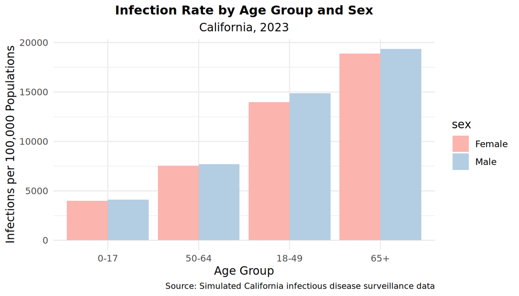

```r
ggplot(df_age_sex,
       aes(x = reorder(age_cat, infection_rate),
           y = infection_rate,
           fill = sex)) +
  geom_col(position = "dodge") +
  scale_fill_brewer(palette = "Pastel1",
                    labels = c("Female", "Male")) +
  labs(
    title = "Infection Rate by Age Group and Sex",
    subtitle = "California, 2023",
    x = "Age Group",
    y = "Infections per 100,000 Populations",
    caption =
    "Source: Simulated California infectious disease surveillance data"
  ) +
  theme_minimal() +
  theme(plot.title = element_text(hjust = 0.5, size = 12, face = "bold"),
        plot.subtitle = element_text(hjust = 0.5, size = 11),
        plot.caption = element_text(size = 8, hjust = 1))
```

4. Infection rate by race/ethnicity

```r
df_race <- aggregated_df %>%
  filter(population > 0) %>%
  group_by(race_ethnicity) %>%
  summarize(
    total_infections = sum(total_infections),
    population = sum(population),
    .groups = "drop"
  ) %>%
  mutate(
    infection_rate = round(total_infections / population * 100000, 1),
    race_ethnicity = case_when(
      race_ethnicity == "White NH" ~ "White",
      race_ethnicity == "Black NH" ~ "Black",
      race_ethnicity == "AIAN NH" ~ "American Indian or Alaska Native",
      race_ethnicity == "Asian NH" ~ "Asian",
      race_ethnicity == "NHPI NH" ~ "Native Hawaiian or Pacific Islander",
      race_ethnicity == "MR NH" ~ "Multiracial",
      race_ethnicity == "Hispanic" ~ "Hispanic")
  )

df_race %>% kable(
  col.names = c("Race/Ethnicity", "Total Infections",
                "Population", "Infection Rate")) %>%
  kable_styling(bootstrap_options = "striped",
                full_width = FALSE,
                position = "center")
```

| Race/Ethnicity | Total Infections | Population | Infection Rate |
| --- | --- | --- | --- |
| American Indian or Alaska Native | 22195 | 158672 | 13988.0 |
| Asian | 546768 | 6295420 | 8685.2 |
| Black | 271836 | 2211518 | 12291.8 |
| Hispanic | 1796695 | 14829946 | 12115.3 |
| Multiracial | 116391 | 1611503 | 7222.5 |
| Native Hawaiian or Pacific Islander | 16917 | 153729 | 11004.4 |
| White | 1778774 | 13848282 | 12844.7 |

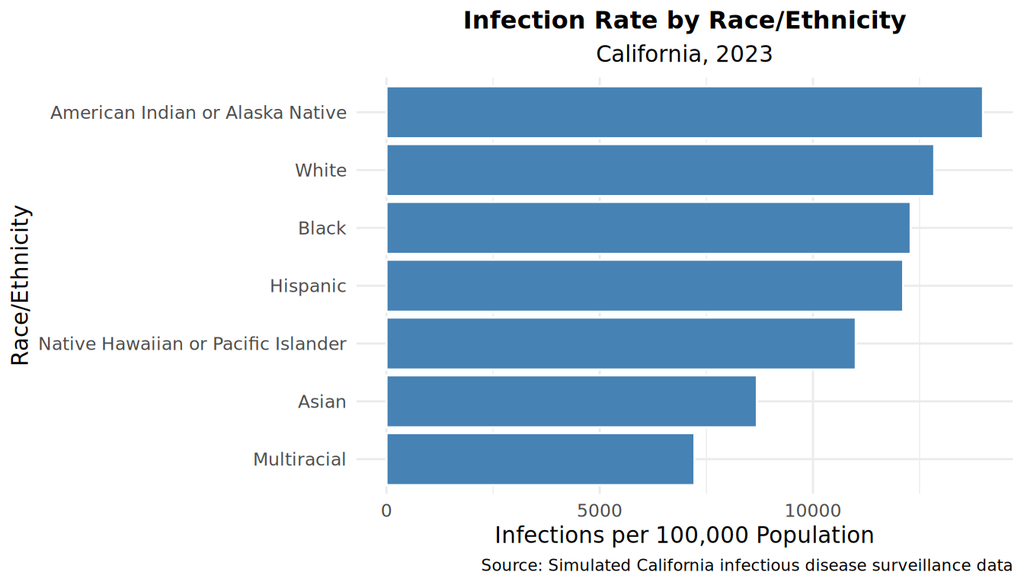

```r
ggplot(df_race,
       aes(x = reorder(race_ethnicity, infection_rate),
           y = infection_rate)) +
  geom_col(fill = "steelblue", color = "white") +
  labs(
    title = "Infection Rate by Race/Ethnicity",
    subtitle = "California, 2023",
    x = "Race/Ethnicity",
    y = "Infections per 100,000 Population",
    caption =
   "Source: Simulated California infectious disease surveillance data"
  ) +
  coord_flip() +
  theme_minimal() +
  theme(plot.title = element_text(hjust = 0.5, size = 12, face = "bold"),
        plot.subtitle = element_text(hjust = 0.5, size = 11),
        plot.caption = element_text(size = 8, hjust = 1))
```

**Interpretation:** The bar graph shows differences in infection rates across racial and ethnic groups in California. American Indian or Alaska Native populations had the highest infection rates, followed by White and Black populations, while multiracial populations had the lowest rates. These findings highlight differences in disease burden across racial and ethnic groups.

**8. Data Dictionary**

1. Basic description provided for all variables
- county: county names
- age_cat: age category “0-17” “18-49” “50-64” “65+”
- sex: male/female
- race_ethnicity: race/ethnicity categorization as defined by CA Dept of Finance “White NH” = “White, Non-Hispanic” “Black NH” = “Black, Non-Hispanic” “AIAN NH” = “American Indian or Alaska Native, Non-Hispanic” “Asian NH” = “Asian, Non-Hispanic” “NHPI NH” = “Native Hawaiian or Pacific Islander, Non-Hispanic” “MR NH” = “Multiracial (two or more of above races), Non-Hispanic” “Hispanic” = “Hispanic (any race)”
- new_infections: number of newly diagnosed individuals
- population: CA Dept of Finance estimated all ages population for year 2023
- diagnosis_month: the month when infections were diagnosed
2. Demographic information (county, age category, sex, race/ethnicity)

| Variable Name | Data Type | Description | Constraints |
| --- | --- | --- | --- |
| county | Character | California county where infections were reported | Valid California county name |
| age_cat | Character | Age category of the population | Standardized age categories |
| sex | Character | Sex of the population | Female or Male |
| race_ethnicity | Character | Race and ethnicity classification | Standardized race/ethnicity categories |
| new_infections | Integer | Number of new infection cases | Non-negative integer |
| population | Integer | Population size for each demographic group | Positive integer |
| diagnosis_month | Ordered factor | Month when infections were diagnosed | May through December in chronological order |

3. Descriptive statistics (new infections, population)

| Statistics | Value |
| --- | --- |
| number_of_counties | 58.0 |
| number_of_age_categories | 4.0 |
| number_of_race_ethnicity_categories | 7.0 |
| mean_infections | 45.2 |
| median_infections | 1.0 |
| max_infections | 12110.0 |
| mean_population | 12041.0 |
| median_population | 683.5 |

4. Relationships and findings

The four tables and graphs illustrate how the simulated infectious disease outbreak varied over time, geographically, and across demographic groups in California.

Monthly new infections increased steadily from May through September, reaching their peak in September before declining in October and November. This pattern suggests that the outbreak intensified throughout the summer months before beginning to subside in the fall.

County-level infection rates revealed geographic differences in disease burden. Imperial, Inyo, Kern, and Tulare counties had some of the highest infection rates per 100,000 residents. These counties generally have smaller populations than California’s largest metropolitan counties, highlighting the importance of using population-adjusted infection rates rather than absolute case counts when comparing disease burden across geographic areas.

Together, these findings demonstrate that the simulated outbreak was not evenly distributed across California’s population. While the monthly trends show when infections were most prevalent, the county and demographic analyses identify which populations experienced the highest infection rates.